# Kaggle Competition: Predicting House Prices

Florence Muriuki

12 July 2017

Objective

To predict house prices based on a data set from Kaggle House Prices Competition

Process

1. Read the data into R and understand its structure and variables
2. Preprocess the data
3. Select features to use in the predictive model
4. Create various predictive model and select the best based on RMSE
5. Submit predictions to Kaggle

```r
library(tidyverse, quietly = TRUE)
library(caret, quietly = TRUE)
library(randomForest, quietly = TRUE)
library(psych, quietly = TRUE)
library(Boruta, quietly = TRUE)
library(moments, quietly = TRUE)
```

Step 1: Read the data into R and understand its structure and variables

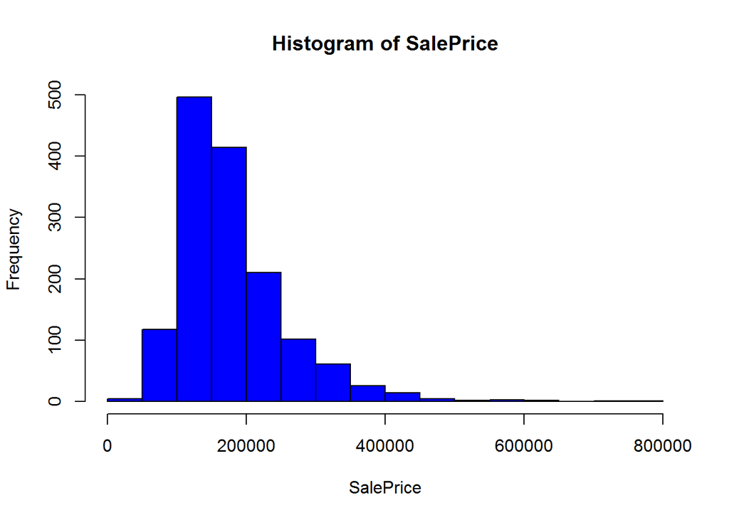

```r
setwd("C:/Users/Chance/Desktop/Portfolio/House Prices")
options(scipen = 5)
train = read.csv("Housetrain.csv") ## load the train data - 1460 rows, 81 columns
test = read.csv("Housetest.csv") ## load the test data - 1459 rows, 80 columns
Id = test$Id # to use later
SalePrice = train$SalePrice ## pick out the SalePrice column for use later
hist(SalePrice, col = "blue") # SalePrice is right tailed (few observations with very large values)
```

```r
print(skewness(SalePrice))
```

```
## [1] 1.880941
```

```r
df = rbind(within(train, rm("Id", "SalePrice")), within(test, rm("Id"))) # combine the training and testing data to make it easier to preprocess the data
str(df)
```

```
## 'data.frame':    2919 obs. of  79 variables:
##  $ MSSubClass   : int  60 20 60 70 60 50 20 60 50 190 ...
##  $ MSZoning     : Factor w/ 5 levels "C (all)","FV",..: 4 4 4 4 4 4 4 4 5 4 ...
##  $ LotFrontage  : int  65 80 68 60 84 85 75 NA 51 50 ...
##  $ LotArea      : int  8450 9600 11250 9550 14260 14115 10084 10382 6120 7420 ...
##  $ Street       : Factor w/ 2 levels "Grvl","Pave": 2 2 2 2 2 2 2 2 2 2 ...
##  $ Alley        : Factor w/ 2 levels "Grvl","Pave": NA NA NA NA NA NA NA NA NA NA ...
##  $ LotShape     : Factor w/ 4 levels "IR1","IR2","IR3",..: 4 4 1 1 1 1 4 1 4 4 ...
##  $ LandContour  : Factor w/ 4 levels "Bnk","HLS","Low",..: 4 4 4 4 4 4 4 4 4 4 ...
##  $ Utilities    : Factor w/ 2 levels "AllPub","NoSeWa": 1 1 1 1 1 1 1 1 1 1 ...
##  $ LotConfig    : Factor w/ 5 levels "Corner","CulDSac",..: 5 3 5 1 3 5 5 1 5 1 ...
##  $ LandSlope    : Factor w/ 3 levels "Gtl","Mod","Sev": 1 1 1 1 1 1 1 1 1 1 ...
##  $ Neighborhood : Factor w/ 25 levels "Blmngtn","Blueste",..: 6 25 6 7 14 12 21 17 18 4 ...
##  $ Condition1   : Factor w/ 9 levels "Artery","Feedr",..: 3 2 3 3 3 3 3 5 1 1 ...
##  $ Condition2   : Factor w/ 8 levels "Artery","Feedr",..: 3 3 3 3 3 3 3 3 3 1 ...
```

[output cut: 65 more lines]

```r
summary(df)
```

```
##    MSSubClass        MSZoning     LotFrontage        LotArea
##  Min.   : 20.00   C (all):  25   Min.   : 21.00   Min.   :  1300
##  1st Qu.: 20.00   FV     : 139   1st Qu.: 59.00   1st Qu.:  7478
##  Median : 50.00   RH     :  26   Median : 68.00   Median :  9453
##  Mean   : 57.14   RL     :2265   Mean   : 69.31   Mean   : 10168
##  3rd Qu.: 70.00   RM     : 460   3rd Qu.: 80.00   3rd Qu.: 11570
##  Max.   :190.00   NA's   :   4   Max.   :313.00   Max.   :215245
##                                  NA's   :486
##   Street      Alley      LotShape   LandContour  Utilities
##  Grvl:  12   Grvl: 120   IR1: 968   Bnk: 117    AllPub:2916
##  Pave:2907   Pave:  78   IR2:  76   HLS: 120    NoSeWa:   1
##              NA's:2721   IR3:  16   Low:  60    NA's  :   2
##                          Reg:1859   Lvl:2622
##
##
##
##    LotConfig    LandSlope   Neighborhood    Condition1     Condition2
##  Corner : 511   Gtl:2778   NAmes  : 443   Norm   :2511   Norm   :2889
##  CulDSac: 176   Mod: 125   CollgCr: 267   Feedr  : 164   Feedr  :  13
##  FR2    :  85   Sev:  16   OldTown: 239   Artery :  92   Artery :   5
##  FR3    :  14              Edwards: 194   RRAn   :  50   PosA   :   4
##  Inside :2133              Somerst: 182   PosN   :  39   PosN   :   4
##                            NridgHt: 166   RRAe   :  28   RRNn   :   2
##                            (Other):1428   (Other):  35   (Other):   2
##    BldgType      HouseStyle    OverallQual      OverallCond
##  1Fam  :2425   1Story :1471   Min.   : 1.000   Min.   :1.000
##  2fmCon:  62   2Story : 872   1st Qu.: 5.000   1st Qu.:5.000
##  Duplex: 109   1.5Fin : 314   Median : 6.000   Median :5.000
##  Twnhs :  96   SLvl   : 128   Mean   : 6.089   Mean   :5.565
##  TwnhsE: 227   SFoyer :  83   3rd Qu.: 7.000   3rd Qu.:6.000
##                2.5Unf :  24   Max.   :10.000   Max.   :9.000
##                (Other):  27
##    YearBuilt     YearRemodAdd    RoofStyle       RoofMatl
##  Min.   :1872   Min.   :1950   Flat   :  20   CompShg:2876
##  1st Qu.:1954   1st Qu.:1965   Gable  :2310   Tar&Grv:  23
##  Median :1973   Median :1993   Gambrel:  22   WdShake:   9
##  Mean   :1971   Mean   :1984   Hip    : 551   WdShngl:   7
##  3rd Qu.:2001   3rd Qu.:2004   Mansard:  11   ClyTile:   1
##  Max.   :2010   Max.   :2010   Shed   :   5   Membran:   1
##                                               (Other):   2
```

[output cut: 89 more lines]

```
##  GdPrv: 118   Gar2:   5   Min.   :    0.00   Min.   : 1.000
##  GdWo : 112   Othr:   4   1st Qu.:    0.00   1st Qu.: 4.000
##  MnPrv: 329   Shed:  95   Median :    0.00   Median : 6.000
##  MnWw :  12   TenC:   1   Mean   :   50.83   Mean   : 6.213
##  NA's :2348   NA's:2814   3rd Qu.:    0.00   3rd Qu.: 8.000
##                           Max.   :17000.00   Max.   :12.000
##
##      YrSold        SaleType    SaleCondition
##  Min.   :2006   WD     :2525   Abnorml: 190
##  1st Qu.:2007   New    : 239   AdjLand:  12
##  Median :2008   COD    :  87   Alloca :  24
##  Mean   :2008   ConLD  :  26   Family :  46
##  3rd Qu.:2009   CWD    :  12   Normal :2402
##  Max.   :2010   (Other):  29   Partial: 245
##                 NA's   :   1
```

```r
naCols = which(colSums(is.na(df)) > 0) # indices of columns with Na values
naCols = sort(colSums(sapply(df[,naCols], is.na)), decreasing = TRUE)
print (naCols) # Columns with missing values ordered from the one with the most NAs to the one with least NAs
```

```
##       PoolQC  MiscFeature        Alley        Fence  FireplaceQu
##         2909         2814         2721         2348         1420
##  LotFrontage  GarageYrBlt GarageFinish   GarageQual   GarageCond
##          486          159          159          159          159
##   GarageType     BsmtCond BsmtExposure     BsmtQual BsmtFinType2
##          157           82           82           81           80
## BsmtFinType1   MasVnrType   MasVnrArea     MSZoning    Utilities
##           79           24           23            4            2
## BsmtFullBath BsmtHalfBath   Functional  Exterior1st  Exterior2nd
##            2            2            2            1            1
##   BsmtFinSF1   BsmtFinSF2    BsmtUnfSF  TotalBsmtSF   Electrical
##            1            1            1            1            1
##  KitchenQual   GarageCars   GarageArea     SaleType
##            1            1            1            1
```

## Structure of the data

The training data has 1460 rows and 81 columns inclusive of the response variable - SalePrice. The testing data has 1459 rows and 80 columns exclusive of the response variable - SalePrice. The first column on both data sets is an Id column indicating the sequential number of row and the rest are variables describing the houses. We combine the training data (having removed SalePrice and Id) and testing data(having removed Id) to ensure similar preprocessing of both data sets. The combined data has 2919 rows and 79 variables.

# Dealing with missing values

## PoolQC - Pool Quality

```r
df[df$PoolArea > 0 & is.na(df$PoolQC), c("PoolArea", "PoolQC")]
```

```
##      PoolArea PoolQC
## 2421      368   <NA>
## 2504      444   <NA>
## 2600      561   <NA>
```

```r
tapply(df$PoolArea, df$PoolQC, mean)
```

```
##     Ex     Fa     Gd
## 359.75 583.50 648.50
```

```r
df$PoolQC = as.character(df$PoolQC)
df[c(2421, 2504), "PoolQC"] = "Ex"
df[2600, "PoolQC"] = "Fa"
df$PoolQC[is.na(df$PoolQC)] = "None"
df$PoolQC = as.factor(df$PoolQC)
```

## MiscFeature - Miscellaneous features such as sheds, elevators, 2nd garage etc

In the MiscVal column (Value of miscellaneous features) we see that 2816 observations take value zero while in the MiscFeature there are 2814 observations. This means that there are 2814 observations without miscellaneous features and 2 properties with miscellaneous values valued at zero indicating a plausible df entry error.

```r
df[c(1201,2432), c("MiscFeature", "MiscVal")]
```

```
##      MiscFeature MiscVal
## 1201        Shed       0
## 2432        Shed       0
```

```r
tapply(df$MiscVal, df$MiscFeature, mean)
```

```
##   Gar2   Othr   Shed   TenC
## 8760.0 3250.0  763.8 2000.0
```

```r
df[c(1201, 2432), c("MiscVal")] = 764 # Correct the df entry errors using the mean value of a shed

# Fill the missing values in MiscFeature with "None" to indicate absence of a miscellaneous feature
df$MiscFeature = as.character(df$MiscFeature)
df$MiscFeature[is.na(df$MiscFeature)] = "None"
df$MiscFeature = as.factor(df$MiscFeature)
```

```r
tapply(df$MiscVal, df$MiscFeature, mean)
```

```
##        Gar2        None        Othr        Shed        TenC
## 8760.000000    6.041222 3250.000000  779.884211 2000.000000
```

```r
df[c(1201, 2432), c("MiscVal")] = 764
```

## Alley - Type of Alley

NA indicate no alley access

```r
df$Alley = as.character(df$Alley)
df$Alley[is.na(df$Alley)] = "None"
df$Alley = as.factor(df$Alley)
```

## Fence

NA indicate no fence

```r
df$Fence = as.character(df$Fence)
df$Fence[is.na(df$Fence)] = "None"
df$Fence = as.factor(df$Fence)
```

## FireplaceQu - Quality of fireplace

```r
table(df$Fireplaces)
```

```
##
##    0    1    2    3    4
## 1420 1268  219   11    1
```

```r
# NA's in FireplaceQu correspond to observations without fireplaces
df$FireplaceQu = as.character(df$FireplaceQu)
df$FireplaceQu[is.na(df$FireplaceQu) & df$Fireplaces == 0 ] = "None"
df$FireplaceQu = as.factor(df$FireplaceQu)
```

## LotFrontage - Linear feet of street connected to property

NA indicate zero feet of street connected to property

```r
df$LotFrontage[is.na(df$LotFrontage)] = 0
```

## Garage variables - GarageArea, GarageCars, GarageFinish, GarageQual, GarageCond, GarageType, GarageYrBlt

Observations taking values 0 or NA in GarageArea and GarageCars indicate that the properties does not have a garage. These observations without a garage will take value “None” in the categorical garage variables and YearBuilt in GarageYrBlt (for convenience because we cannot use year 0 and 80% of observations with a garage have similar YearBuilt and GarageYrBlt). Row 2127 has a garage thus missing values in some garage variables in this row will be filled appropriately

```r
df$GarageArea[2577] = 0 # row 2577 has NA in both GarageArea and GarageCars thus we can assume it does
# not have a garage
df$GarageCars[2577] = 0
noGarage = which(df$GarageArea == 0 )
garageVars = c("GarageFinish", "GarageQual", "GarageCond", "GarageType")
df[,garageVars] = sapply(df[,garageVars], as.character)
df[noGarage, garageVars] = "None"
df$GarageFinish[c(2127, 2577)] = "Unf"
df$GarageCond[c(2127, 2577)] = "TA"
df$GarageQual[c(2127, 2577)] = "TA"
df$GarageYrBlt[2127] = df$YearBuilt[2127]

df$GarageCond = as.factor(df$GarageCond)
df$GarageFinish = as.factor(df$GarageFinish)
df$GarageQual = as.factor(df$GarageQual)
df$GarageType = as.factor(df$GarageType)
df$GarageYrBlt[is.na(df$GarageYrBlt)] = df$YearBuilt[is.na(df$GarageYrBlt)]
df$GarageYrBlt[2593] = df$YearBuilt[2593] # row 2593 has value 2207 in GarageYearBuilt
```

## Basement (Variables describing the basement):BsmtQual, BsmtCond, BsmtExposure, BsmtFinType1,

## BsmtFinType2, BsmtFinSF1, BsmtFinSF2, BsmtUnfSF, TotalBsmtSF, BsmtFullBath, BsmtHalfBath

We can infer that row 2121 does not have a basement because it takes NA in all the basement variables. Observations taking value 0 in TotalBsmtSF indicate the absence of basements. Categorical variables in these observations will take value “None” and numerical variables will take value 0.

```r
df$TotalBsmtSF[2121] = 0
noBasement = which(df$TotalBsmtSF == 0) #79
basVars = select(df, contains("Bsmt"))
summary(basVars[noBasement,])
```

```
##  BsmtQual  BsmtCond  BsmtExposure BsmtFinType1   BsmtFinSF1 BsmtFinType2
##  Ex  : 0   Fa  : 0   Av  : 0      ALQ : 0      Min.   :0    ALQ : 0
##  Fa  : 0   Gd  : 0   Gd  : 0      BLQ : 0      1st Qu.:0    BLQ : 0
##  Gd  : 0   Po  : 0   Mn  : 0      GLQ : 0      Median :0    GLQ : 0
##  TA  : 0   TA  : 0   No  : 0      LwQ : 0      Mean   :0    LwQ : 0
##  NA's:79   NA's:79   NA's:79      Rec : 0      3rd Qu.:0    Rec : 0
##                                   Unf : 0      Max.   :0    Unf : 0
##                                   NA's:79      NA's   :1    NA's:79
##    BsmtFinSF2   BsmtUnfSF  TotalBsmtSF  BsmtFullBath  BsmtHalfBath
##  Min.   :0    Min.   :0   Min.   :0    Min.   :0     Min.   :0
##  1st Qu.:0    1st Qu.:0   1st Qu.:0    1st Qu.:0     1st Qu.:0
##  Median :0    Median :0   Median :0    Median :0     Median :0
##  Mean   :0    Mean   :0   Mean   :0    Mean   :0     Mean   :0
##  3rd Qu.:0    3rd Qu.:0   3rd Qu.:0    3rd Qu.:0     3rd Qu.:0
##  Max.   :0    Max.   :0   Max.   :0    Max.   :0     Max.   :0
##  NA's   :1    NA's   :1                NA's   :2     NA's   :2
```

```r
basVarsFactors = c("BsmtQual", "BsmtCond", "BsmtExposure", "BsmtFinType1", "BsmtFinType2")
df[, basVarsFactors] = sapply(df[,basVarsFactors], as.character)
df[noBasement,basVarsFactors] = "None"
df$BsmtCond[is.na(df$BsmtCond)] = "TA"
df$BsmtQual[is.na(df$BsmtQual)] = "TA"
df$BsmtQual = as.factor(df$BsmtQual)
df$BsmtCond = as.factor(df$BsmtCond)
tapply(df$TotalBsmtSF, df$BsmtExposure, median)
```

```
##   Av   Gd   Mn   No None
## 1138 1472 1078  936    0
```

```r
tapply(df$TotalBsmtSF, df$BsmtExposure, mean)
```

```
##        Av        Gd        Mn        No      None
## 1186.8397 1475.1812 1111.9958  996.2264    0.0000
```

```r
df$BsmtExposure[c(949,2349)] = "No"
df$BsmtExposure[1488] = "No"
df$BsmtExposure = as.factor(df$BsmtExposure)
df$BsmtFinType1 = as.factor(df$BsmtFinType1)
df$BsmtFinType2[333] = df$BsmtFinType1[333]
df$BsmtFinType2 = as.factor(df$BsmtFinType2)
basVarsNum = c("BsmtFinSF1", "BsmtFinSF2", "BsmtUnfSF", "TotalBsmtSF", "BsmtFullBath", "BsmtHalfBath")
df[noBasement, basVarsNum ] = 0
```

## MasVnrType and MasVnrArea - Masonry veneer type and area respectively

Some houses do not have masonry veneer. Houses with missing values in both MasVnrType and MasVnrArea are likely to not have masonry veneer. Row 2611 has MasVnrArea > 0 but NA in MasVnrType

```r
naMasVnr = which(is.na(df$MasVnrType) & is.na(df$MasVnrArea)) #23 rows
df$MasVnrType = as.character(df$MasVnrType)
df$MasVnrType[naMasVnr] = "None"
df$MasVnrType = as.factor(df$MasVnrType) #row 2611 has MasVnrArea > 0 but NA in MasVnrType
df$MasVnrArea[naMasVnr] = 0
tapply(df$MasVnrArea, df$MasVnrType, mean)
```

```
##     BrkCmn    BrkFace       None      Stone
## 195.480000 261.672355   0.698017 239.550201
```

```r
df$MasVnrType = as.character(df$MasVnrType)
df$MasVnrType[2611] = "BrkCmn"
df$MasVnrType = as.factor(df$MasVnrType)
```

## Functional

```r
tapply(df$OverallCond, df$Functional, mean)
```

```
##     Maj1     Maj2     Min1     Min2      Mod      Sev      Typ
## 4.421053 3.888889 5.615385 5.557143 5.057143 3.000000 5.587413
```

```r
naFunctional = which(is.na(df$Functional))
df[naFunctional, "OverallCond"]
```

```
## [1] 5 1
```

```r
df$Functional = as.character(df$Functional)
df$Functional[2217] = "Mod"
df$Functional[2474] = "Sev"
df$Functional = as.factor(df$Functional)
```

## MSZoning

```r
naMSZoning = which(is.na(df$MSZoning))
table(df$Neighborhood, df$MSZoning)# Majority of houses in IDOTRR are in RM zone and those in Mitchel are in RL
```

```
##
##           C (all)  FV  RH  RL  RM
##   Blmngtn       0   0   0  25   3
##   Blueste       0   0   0   0  10
##   BrDale        0   0   0   0  30
##   BrkSide       0   0   0  43  65
##   ClearCr       0   0   0  44   0
##   CollgCr       0   0   0 253  14
##   Crawfor       0   0   2  91  10
##   Edwards       0   0   2 180  12
##   Gilbert       0   0   0 165   0
##   IDOTRR       22   0   0   0  68
##   MeadowV       0   0   0   0  37
##   Mitchel       0   0   0 104   9
##   NAmes         0   0   7 436   0
##   NoRidge       0   0   0  71   0
##   NPkVill       0   0   0  23   0
##   NridgHt       0   0   0 165   1
##   NWAmes        0   0   0 131   0
##   OldTown       2   0   0  39 198
##   Sawyer        0   0   0 148   3
##   SawyerW       0   0   6 119   0
##   Somerst       0 139   0  43   0
##   StoneBr       0   0   0  51   0
##   SWISU         1   0   9  38   0
##   Timber        0   0   0  72   0
##   Veenker       0   0   0  24   0
```

```r
df[naMSZoning, "Neighborhood"]
```

```
## [1] IDOTRR  IDOTRR  IDOTRR  Mitchel
## 25 Levels: Blmngtn Blueste BrDale BrkSide ClearCr CollgCr ... Veenker
```

```r
df$MSZoning = as.character(df$MSZoning)
df$MSZoning[c(1916, 2217,2251)] = "RM"
df$MSZoning[2905] = "RL"
df$MSZoning = as.factor(df$MSZoning)
```

## Utilities - Types of utilities: Electricity, Gas, Water in various combinations

```r
naUtilities = which(is.na(df$Utilities))
df[naUtilities, c("Utilities", "Electrical", "Heating")] # We know they have an electrical system and
```

```
##      Utilities Electrical Heating
## 1916      <NA>      FuseA    GasA
## 1946      <NA>      FuseA    GasA
```

```r
# gas for heating. We fill the NAs with the most frequent value
table(df$Utilities)
```

```
##
## AllPub NoSeWa
##   2916      1
```

```r
df$Utilities = as.character(df$Utilities)
df$Utilities[naUtilities] = "AllPub"
df$Utilities = as.factor(df$Utilities)
```

## Electrical

```r
which(is.na(df$Electrical))
```

```
## [1] 1380
```

```r
df[1380,]
```

```
##      MSSubClass MSZoning LotFrontage LotArea Street Alley LotShape
## 1380         80       RL          73    9735   Pave  None      Reg
##      LandContour Utilities LotConfig LandSlope Neighborhood Condition1
## 1380         Lvl    AllPub    Inside       Gtl       Timber       Norm
##      Condition2 BldgType HouseStyle OverallQual OverallCond YearBuilt
## 1380       Norm     1Fam       SLvl           5           5      2006
##      YearRemodAdd RoofStyle RoofMatl Exterior1st Exterior2nd MasVnrType
## 1380         2007     Gable  CompShg     VinylSd     VinylSd       None
##      MasVnrArea ExterQual ExterCond Foundation BsmtQual BsmtCond
## 1380          0        TA        TA      PConc       Gd       TA
##      BsmtExposure BsmtFinType1 BsmtFinSF1 BsmtFinType2 BsmtFinSF2
## 1380           No          Unf          0          Unf          0
##      BsmtUnfSF TotalBsmtSF Heating HeatingQC CentralAir Electrical
## 1380       384         384    GasA        Gd          Y       <NA>
##      X1stFlrSF X2ndFlrSF LowQualFinSF GrLivArea BsmtFullBath BsmtHalfBath
## 1380       754       640            0      1394            0            0
##      FullBath HalfBath BedroomAbvGr KitchenAbvGr KitchenQual TotRmsAbvGrd
## 1380        2        1            3            1          Gd            7
##      Functional Fireplaces FireplaceQu GarageType GarageYrBlt GarageFinish
## 1380        Typ          0        None    BuiltIn        2007          Fin
##      GarageCars GarageArea GarageQual GarageCond PavedDrive WoodDeckSF
## 1380          2        400         TA         TA          Y        100
##      OpenPorchSF EnclosedPorch X3SsnPorch ScreenPorch PoolArea PoolQC
## 1380           0             0          0           0        0   None
##      Fence MiscFeature MiscVal MoSold YrSold SaleType SaleCondition
## 1380  None        None       0      5   2008       WD        Normal
```

```r
df$Electrical = as.character(df$Electrical)
df$Electrical[1380] = "SBrkr"
df$Electrical = as.factor(df$Electrical)
```

## KitchenQual - Kitchen quality

```r
which(is.na(df$KitchenQual))
```

```
## [1] 1556
```

```r
df$KitchenQual = as.character(df$KitchenQual)
df$KitchenQual[1556] = "TA"
df$KitchenQual = as.factor(df$KitchenQual)
```

## SaleType

```r
df$SaleType = as.character(df$SaleType)
df$SaleType[is.na(df$SaleType)] = "WD"
df$SaleType = as.factor(df$SaleType)
```

## Exterior1st and Exterior2nd

```r
df[2152, c("Exterior1st", "Exterior2nd")] = "VinylSd"
```

Any remaining NA’s?

```r
naCols = which(colSums(is.na(df)) > 0) # indices of columns with Na values
length(naCols)
```

```
## [1] 0
```

Hurray! No NAs

# When shopping for a house, what would we consider?

## Location

Which neighborhood do we prefer? How much will it cost us to get a house in that area? Could we get similar houses in a different neighbood? Do we prefer a hilly or flat area? Which amenities do we like to have nearby?

Variables related to the physical location of property: MSZoning, LandContour, LandSlope, Neighborhood, Condition1, Condition2

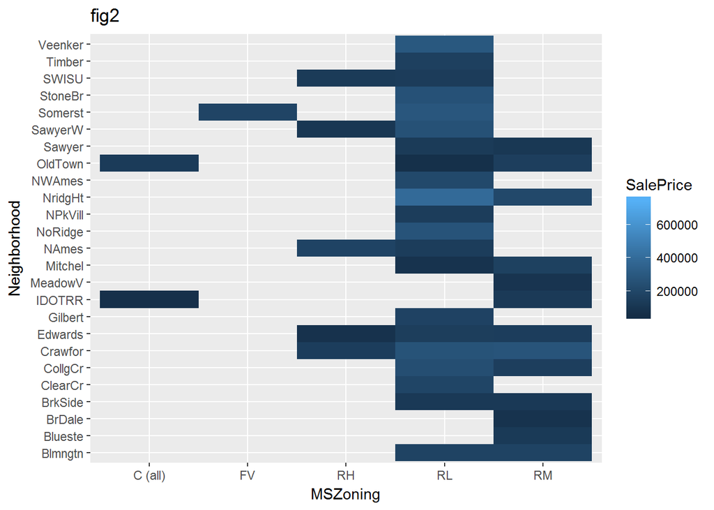

```r
locVars = c("MSZoning", "LandSlope", "Neighborhood", "Condition1", "Condition2")
##ggplot(df, aes(MSZoning, Neighborhood)) + geom_tile(aes(fill = LandSlope)) + labs(title = "fig1")
par(mfrow = c(1,2))
ggplot(df[1:1460,], aes(MSZoning, Neighborhood)) + geom_tile(aes(fill = SalePrice)) + labs(title = "fig2")
```

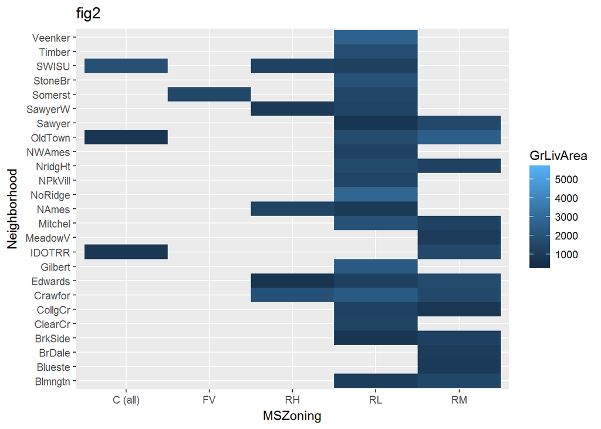

```r
##ggplot(df[1:1460,], aes(Condition1, Neighborhood)) + geom_tile(aes(fill = SalePrice)) + labs(title = "fig3")
ggplot(df, aes(MSZoning, Neighborhood)) + geom_tile(aes(fill = GrLivArea)) + labs(title = "fig2")
```

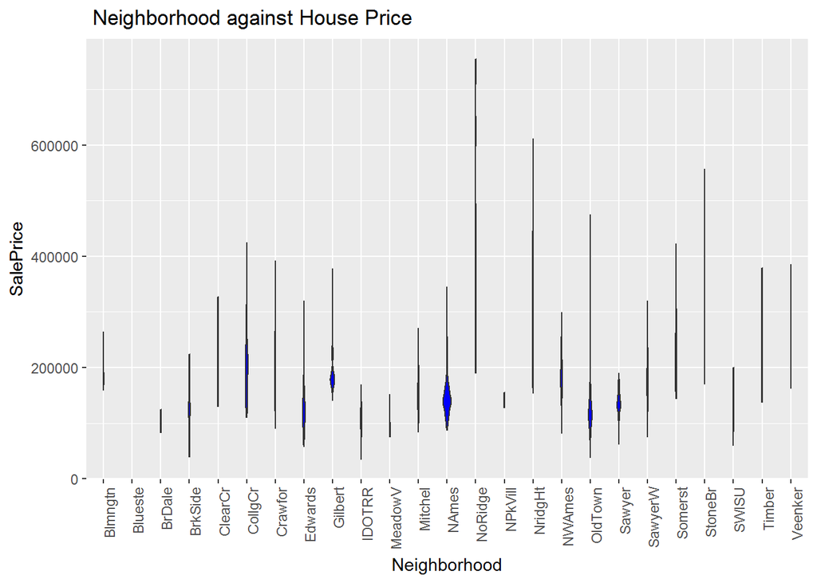

```r
ggplot(df[1:1460,], aes(x = Neighborhood, y = SalePrice)) + geom_violin(scale = "count", fill = "blue") +theme(axis.text.x = element_text(angle = 90, hjust = 1)) +labs(title = " Neighborhood against House Price")
```

## Type and style of house

Do we want a specific type of house? Do we prefer a house built with particular materials? Will it cost us more to get a house that fits our taste?

Variables related to type, style and building material of property: MSSubClass, BldgType, HouseStyle, RoofStyle, MasVnrArea, MasVnrType, RoofMatl, Exterior1st, Exterior2nd, MSSubClass

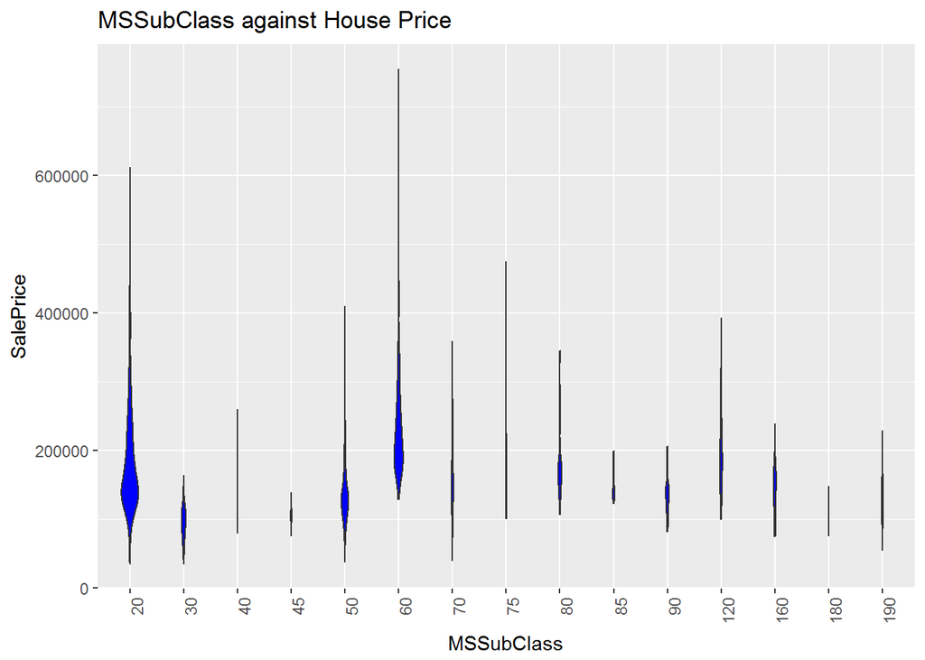

```r
par(mfrow = c(4,4))
# Convert MSSubClass into a factor variable
df$MSSubClass = as.factor(df$MSSubClass)
ggplot(df[1:1460,], aes(x = MSSubClass, y = SalePrice)) + geom_violin(scale = "count", fill = "blue") +theme(axis.text.x = element_text(angle = 90, hjust = 1)) +labs(title = "MSSubClass against House Price")
```

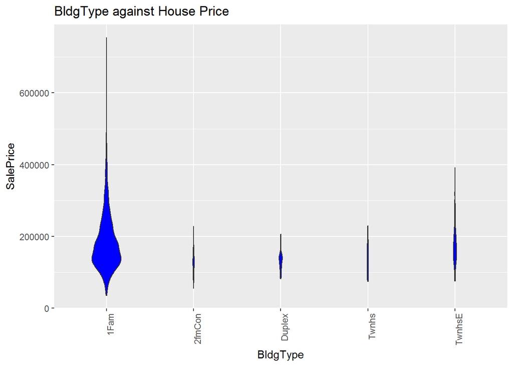

```r
# BldgType
ggplot(df[1:1460,], aes(x = BldgType, y = SalePrice)) + geom_violin(scale = "count", fill = "blue") +theme(axis.text.x = element_text(angle = 90, hjust = 1)) +labs(title = "BldgType against House Price")
```

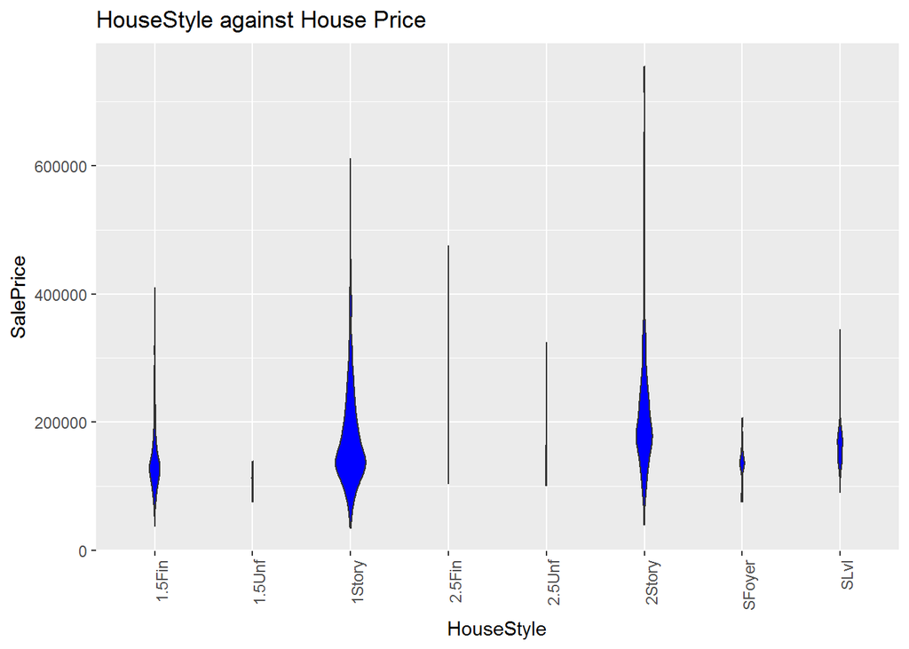

```r
# HouseStyle
ggplot(df[1:1460,], aes(x = HouseStyle, y = SalePrice)) + geom_violin(scale = "count", fill = "blue") +theme(axis.text.x = element_text(angle = 90, hjust = 1)) +labs(title = "HouseStyle against House Price")
```

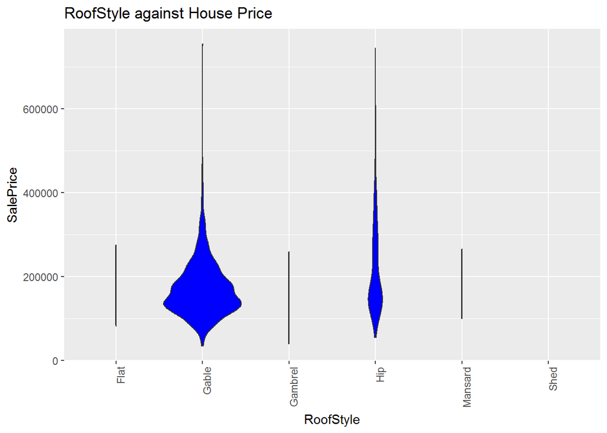

```r
# RoofStyle
ggplot(df[1:1460,], aes(x = RoofStyle, y = SalePrice)) + geom_violin(scale = "count", fill = "blue") +theme(axis.text.x = element_text(angle = 90, hjust = 1)) +labs(title = "RoofStyle against House Price")
```

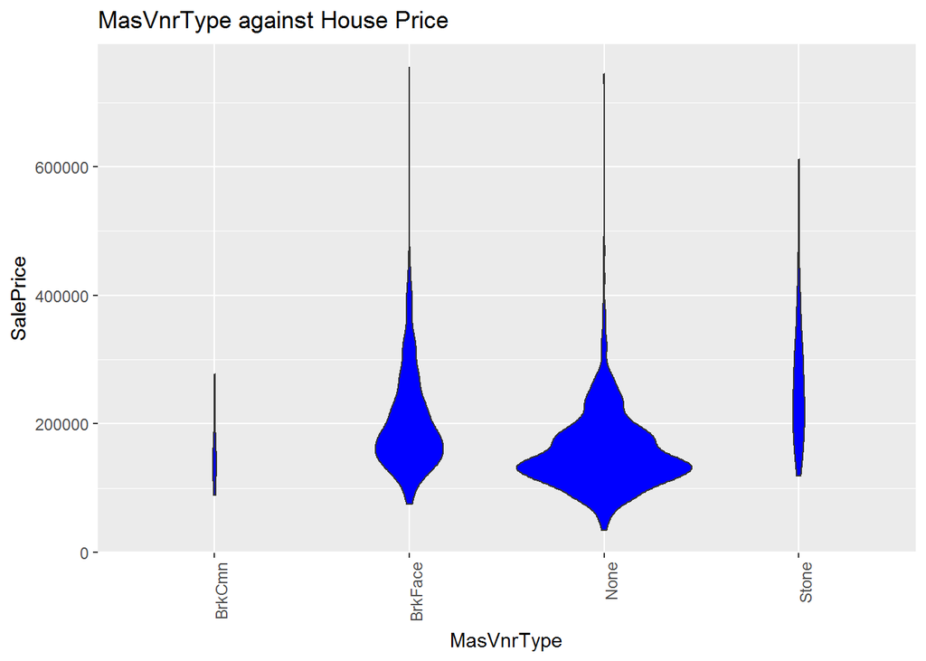

```r
# MasVnrType

ggplot(df[1:1460,], aes(x = MasVnrType, y = SalePrice)) + geom_violin(scale = "count", fill = "blue") +theme(axis.text.x = element_text(angle = 90, hjust = 1)) +labs(title = "MasVnrType against House Price")
```

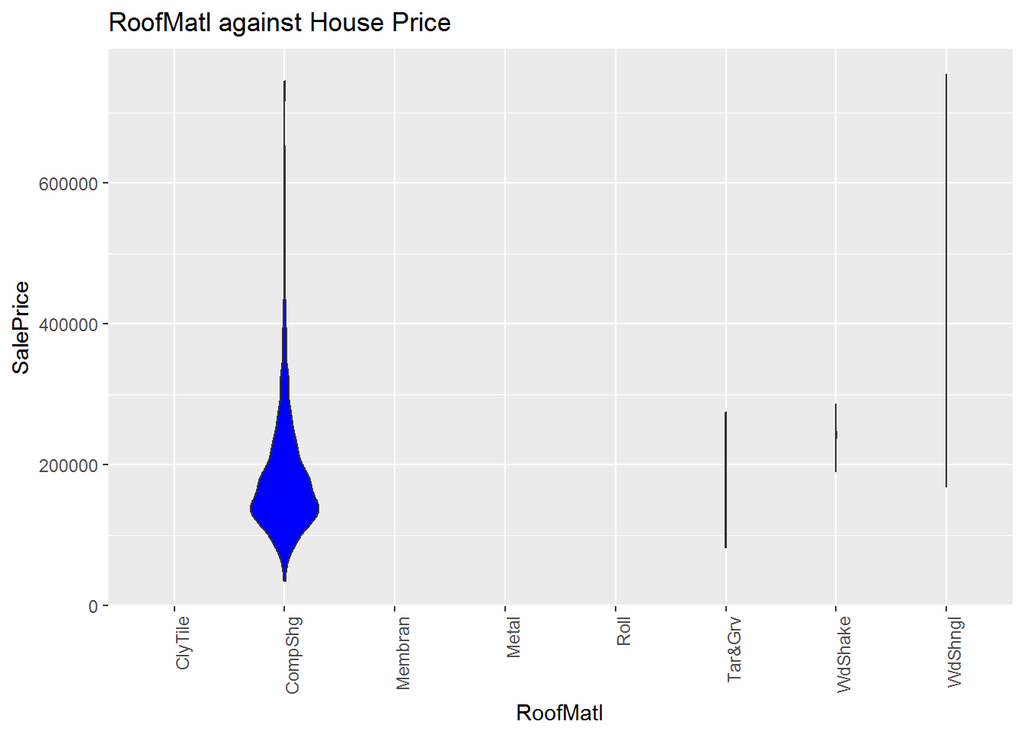

```r
# RoofMatl
ggplot(df[1:1460,], aes(x = RoofMatl, y = SalePrice)) + geom_violin(scale = "count", fill = "blue") +theme(axis.text.x = element_text(angle = 90, hjust = 1)) +labs(title = "RoofMatl against House Price")
```

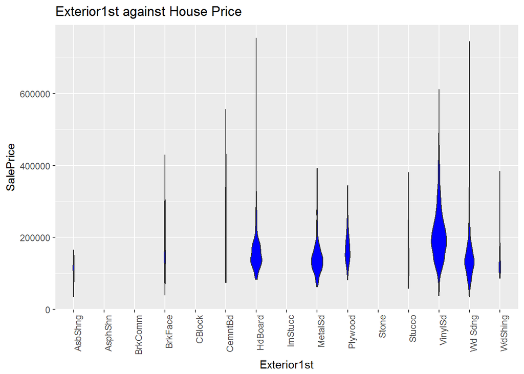

```r
# Exterior1st
ggplot(df[1:1460,], aes(x = Exterior1st, y = SalePrice)) + geom_violin(scale = "count", fill = "blue") +theme(axis.text.x = element_text(angle = 90, hjust = 1)) +labs(title = "Exterior1st against House Price")
```

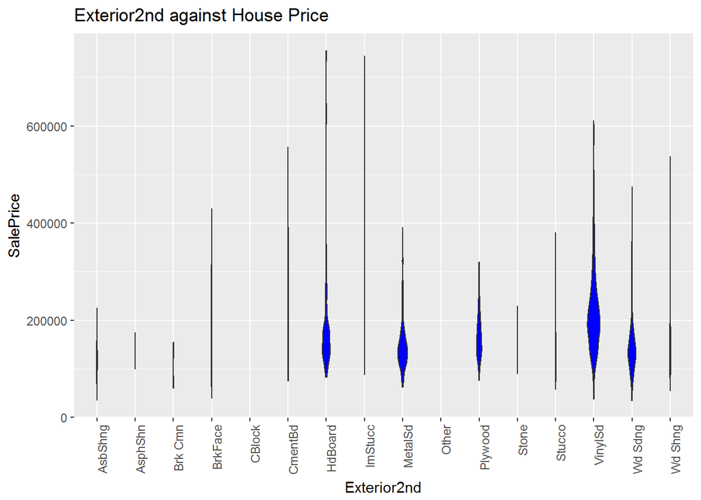

```r
# Exterior2nd
ggplot(df[1:1460,], aes(x = Exterior2nd, y = SalePrice)) + geom_violin(scale = "count", fill = "blue") +theme(axis.text.x = element_text(angle = 90, hjust = 1)) +labs(title = "Exterior2nd against House Price")
```